# Assighnment 6:Nonlinear Regression

2024-10-06

# Step 1: Importing and cleaning data

```r
# Load necessary libraries
library(tidyverse)
# Load the dataset
df <- read.csv('StudentPerformanceFactors.csv')

# Convert categorical columns to numeric using dummy encoding
df <- df %>%
  mutate_if(is.factor, as.numeric)

# Check for missing values
sapply(df, function(x) sum(is.na(x)))
```

```
##              Hours_Studied                 Attendance
##                          0                          0
##       Parental_Involvement        Access_to_Resources
##                          0                          0
## Extracurricular_Activities                Sleep_Hours
##                          0                          0
##            Previous_Scores           Motivation_Level
##                          0                          0
##            Internet_Access          Tutoring_Sessions
##                          0                          0
##              Family_Income            Teacher_Quality
##                          0                          0
##                School_Type             Peer_Influence
##                          0                          0
##          Physical_Activity      Learning_Disabilities
##                          0                          0
##   Parental_Education_Level         Distance_from_Home
##                          0                          0
##                     Gender                 Exam_Score
##                          0                          0
```

```r
# Replace blanks with 0
df[is.na(df)] <- 0 # Replace NAs with 0

# Select a few relevant variables
selected_vars <- df %>% select(Attendance, Previous_Scores, Motivation_Level, Exam_Score)

# Convert Motivation_Level from character to factor and then to numeric
selected_vars$Motivation_Level <- as.numeric(factor(selected_vars$Motivation_Level, levels = c("Low", "Medium", "High")))

# Check the structure of selected_vars
str(selected_vars)
```

```
## 'data.frame':    6607 obs. of  4 variables:
##  $ Attendance      : int  84 64 98 89 92 88 84 78 94 98 ...
##  $ Previous_Scores : int  73 59 91 98 65 89 68 50 80 71 ...
##  $ Motivation_Level: num  1 1 2 2 2 2 1 2 3 2 ...
##  $ Exam_Score      : int  67 61 74 71 70 71 67 66 69 72 ...
```

# Step 2: Visualizing Results

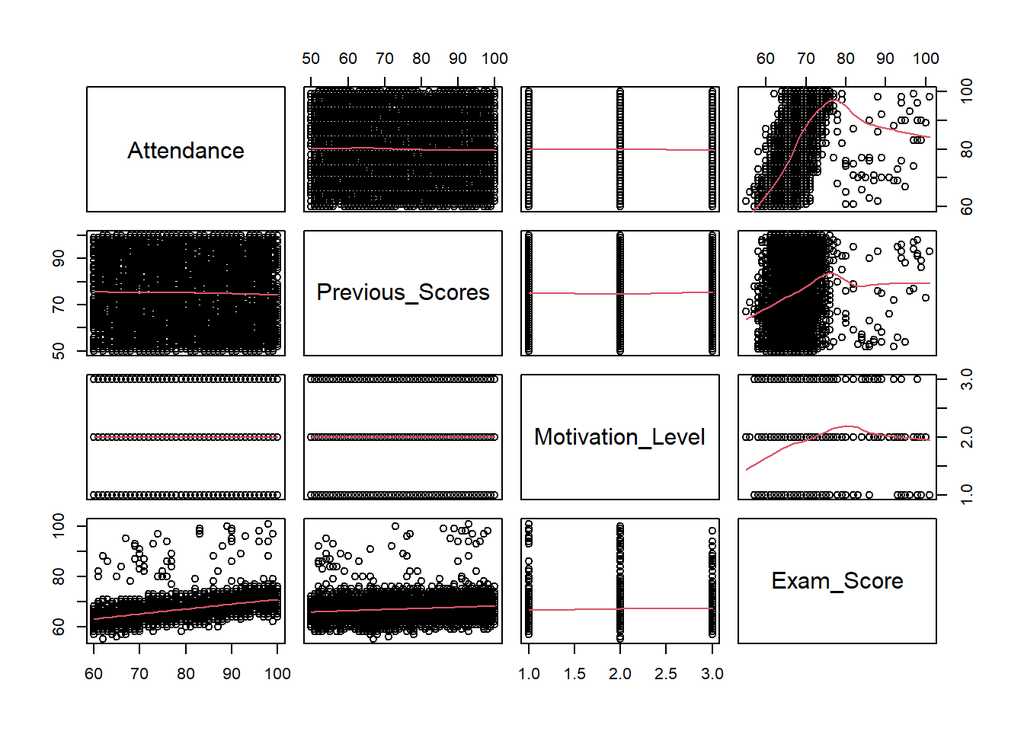

```r
# Use pairs to visualize relationships
pairs(selected_vars, panel = panel.smooth)
```

# Step 3: Choose and Run a Nonlinear Model

```r
# Fit a polynomial regression model (degree 2)
model_nonlinear <- lm(Exam_Score ~ poly(Attendance, 2) + poly(Previous_Scores, 2) + poly(Motivation_Level, 2), data = selected_vars)

# Show the summary of the model
summary(model_nonlinear)
```

```
##
## Call:
## lm(formula = Exam_Score ~ poly(Attendance, 2) + poly(Previous_Scores,
##     2) + poly(Motivation_Level, 2), data = selected_vars)
##
## Residuals:
##     Min      1Q  Median      3Q     Max
## -8.3557 -1.7302 -0.1399  1.4097 31.0487
##
## Coefficients:
##                             Estimate Std. Error  t value Pr(>|t|)
## (Intercept)                 67.23566    0.03768 1784.589   <2e-16 ***
## poly(Attendance, 2)1       185.03469    3.06328   60.404   <2e-16 ***
## poly(Attendance, 2)2        -4.28606    3.06295   -1.399    0.162
## poly(Previous_Scores, 2)1   58.94156    3.06386   19.238   <2e-16 ***
## poly(Previous_Scores, 2)2    4.91041    3.06270    1.603    0.109
## poly(Motivation_Level, 2)1  28.03590    3.06254    9.154   <2e-16 ***
## poly(Motivation_Level, 2)2  -3.08362    3.06375   -1.006    0.314
## ---
## Signif. codes:  0 '***' 0.001 '**' 0.01 '*' 0.05 '.' 0.1 ' ' 1
##
## Residual standard error: 3.062 on 6600 degrees of freedom
## Multiple R-squared:  0.3809, Adjusted R-squared:  0.3804
## F-statistic: 676.9 on 6 and 6600 DF,  p-value: < 2.2e-16
```

# Result explanations

This nonlinear model uses polynomial regression at degree 2 modelling Exam _Score against the independent variables Attendance, Previous_Scores, and Motivation_Level. The adjusted R squared score of (0.3804) indicates that the model can explain about (38%) of the variability of Exam_Score. The detected substantial significant predictors are Attendance, Previous_Scores and Motivation_Level with large positive effects of their first-degree terms on Exam_Score: Attendance p < 2e-16, Previous_Scores p < 2e-16 and Motivation_Level p < 2e-16. Similarly, for all variables, the second-degree terms are insignificant (p > 0.05), suggesting no extra advantage to using higher-degree terms. The residual standard error of (3.062) indicates a relatively high variability in exam scores not accounted for through the model.

# Step 4: Model Results and Visualize the model results:

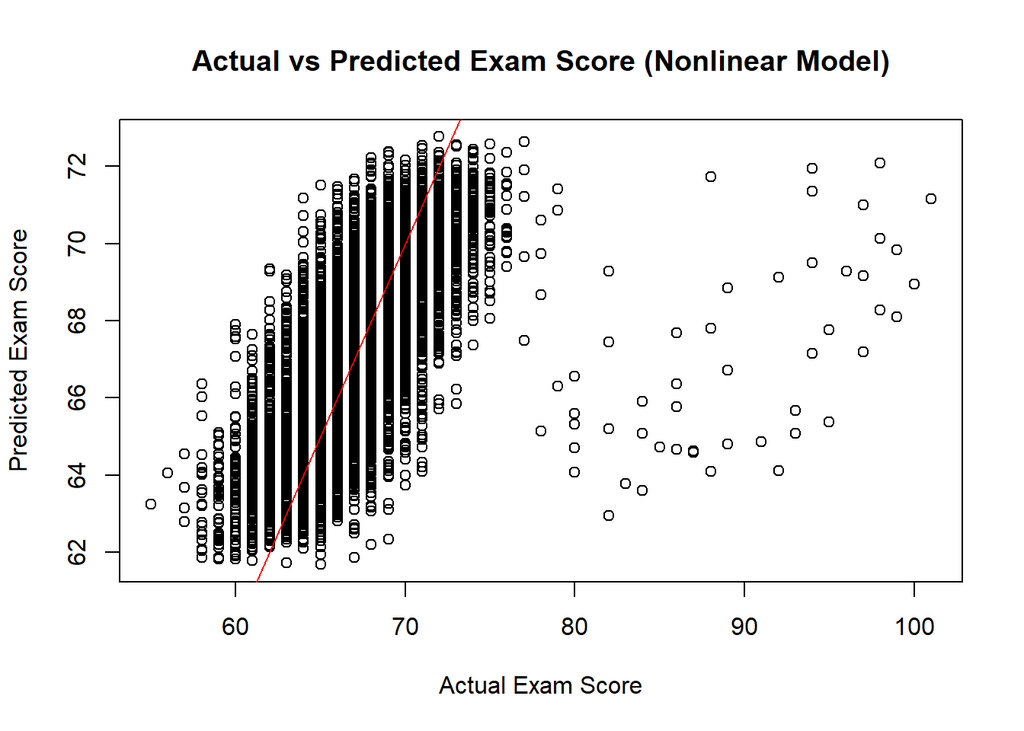

```r
## Visualizing the model Result
# Plot the actual vs predicted values
predicted_values <- predict(model_nonlinear, newdata = selected_vars)

# Create a scatter plot for actual vs predicted values
plot(selected_vars$Exam_Score, predicted_values, xlab = "Actual Exam Score", ylab = "Predicted Exam Score", main = "Actual vs Predicted Exam Score (Nonlinear Model)")
abline(0, 1, col = "red") # Add a reference line
```

## Explanations of the model results

This graph presents the actual and model-fitted raw scores on the exam based on a nonlinear model. This red line, transcendent on the graph, is the reference line of an ideal prediction where the actual values should match the predicted values. It consists of points where most predicted values (y-axis) range from 64 to 72, irrespective of the actual exam scores (x-axis). This means the model works better with lower actual exam scores of 60-75 and yields underpredictions for higher actual exam scores. This means that though the model can explain some of the variation for lower exam results, there is room for improvement in explaining variation for improved exam performance. Hence, the prediction quality becomes low.

## Justification for the model chosen

Polynomial regression model (degree 2) was used because it can describe a nonlinear relationship between independent variables (Attendance, previous scores, and motivation level) and exam Scores. This model permits nonlinear relationships, which may help predict the existing performance compared to the linear model. However, while all the first-degree terms were significant predictors of visitation, the second-degree terms were not, meaning there is no reason to use a more complex model. The adjusted (R² of 0.3804) shows moderate fitness; consequently, the model license accounts for 38% of the examination score variability.

# Step 5: Comparison to Linear Model

```r
# Fit a linear regression model
model_linear <- lm(Exam_Score ~ Attendance + Previous_Scores + Motivation_Level, data = selected_vars)

# Show the summary of the linear model
summary(model_linear)
```

```
##
## Call:
## lm(formula = Exam_Score ~ Attendance + Previous_Scores + Motivation_Level,
##     data = selected_vars)
##
## Residuals:
##     Min      1Q  Median      3Q     Max
## -8.3309 -1.7294 -0.1429  1.4074 31.0431
##
## Coefficients:
##                   Estimate Std. Error t value Pr(>|t|)
## (Intercept)      46.741120   0.347749 134.410   <2e-16 ***
## Attendance        0.197186   0.003264  60.407   <2e-16 ***
## Previous_Scores   0.050339   0.002618  19.230   <2e-16 ***
## Motivation_Level  0.495765   0.054164   9.153   <2e-16 ***
## ---
## Signif. codes:  0 '***' 0.001 '**' 0.01 '*' 0.05 '.' 0.1 ' ' 1
##
## Residual standard error: 3.063 on 6603 degrees of freedom
## Multiple R-squared:  0.3804, Adjusted R-squared:  0.3801
## F-statistic:  1351 on 3 and 6603 DF,  p-value: < 2.2e-16
```

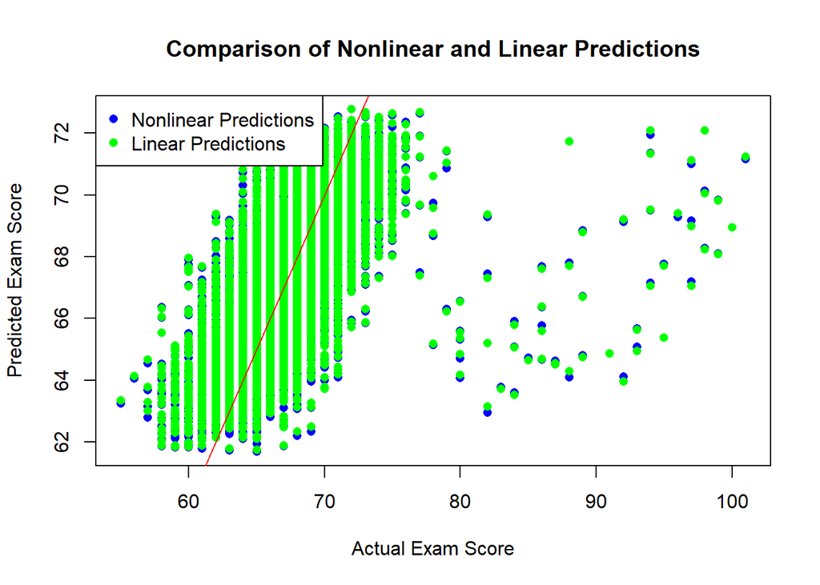

```r
# Predict using the linear model
predicted_linear <- predict(model_linear, newdata = selected_vars)

# Plot for comparison
plot(selected_vars$Exam_Score, predicted_values, col = "blue", pch = 16, xlab = "Actual Exam Score", ylab = "Predicted Exam Score", main = "Comparison of Nonlinear and Linear Predictions")
points(selected_vars$Exam_Score, predicted_linear, col = "green", pch = 16)
legend("topleft", legend = c("Nonlinear Predictions", "Linear Predictions"), col = c("blue", "green"), pch = 16)
abline(0, 1, col = "red") # Add a reference line
```

## Model comparison Explanations

The performance comparison between the two models summarized that both models exhibit a similar level of performance. Examining the linear model’s results produces an adjusted R² of 0.3801, which indicates that the model accounts for nearly 38% of Exam Scores’ variability; the nonlinear model, on the other hand, has an adjusted R² of 0.380 4. These two models mark Attendance, Previous Scores, and Motivation Level as variables that predict the result (p < 2e-16). The residual standard error of the linear model (3.063) is slightly higher than the nonlinear model (3.062), meaning that adding polynomial terms does not impact model fit. Therefore, the linear model we analyzed above is much more straightforward and equally effective.

# Step 6: Interpret and Evaluate Results

```r
# Calculate Mean Squared Error (MSE) for both models
mse_nonlinear <- mean((selected_vars$Exam_Score - predicted_values)^2)
mse_linear <- mean((selected_vars$Exam_Score - predicted_linear)^2)

cat("Mean Squared Error (Nonlinear Model):", mse_nonlinear, "\n")
```

```
## Mean Squared Error (Nonlinear Model): 9.368435
```

```r
cat("Mean Squared Error (Linear Model):", mse_linear, "\n")
```

```
## Mean Squared Error (Linear Model): 9.376364
```

## Explanation of result

Mean Squared Error (MSE) is applied to compare the performance of the nonlinear and the linear models in terms of their capability to predict Exam_Score. Therefore, the MSE for the nonlinear model is 9.368, and for the Linear model, we have 9.376. In this case, the nonlinear model has a slightly lower MSE in the exam scores’ prediction than the linear one. However, what comes as a surprise is that the change of MSE is relatively insignificant, so introducing nonlinearity by including polynomial terms up to degree 2 does not remarkably enhance the model’s ability to fit. This suggests that a linear model could be as equitable as the nonlinear model regarding this dataset, and the polynomial terms are not required.

# General interpretations and evaluations

The simple nonlinear regression test shows that even with polynomial regression analysis of the second degree, the variability in the exam scores can only be partially explained. Using Attendance, Previous Scores, and Motivation Level as the predictor variables, the regression model acquired a moderate indication of the exam performance’s variance with an adjusted R² of (0.3804). While the first-degree terms are found to be good predictors, the second-degree terms are insignificant and do not add any extra explanation. The Mean Squared Error (MSE) of the nonlinear model is (9.368), thus is slightly lower than the linear model’s MSE (9.376), which suggests that the increased model complexity of the nonlinear approach does not improve the measure of accuracy in this case.